# Exploring the 3-body Problem (Part I, Jacobi coordinates and Symplectic Integration)

## Joseph E. McEwen (c) 2017

Please report all errors, typos, etc.

#### What is this notebook?

- some fun with the 3-body problem, symplectic integrators, and learning [Julia](https://julialang.org/)
- disclaimer: I am still learning Julia - please point out areas of improvement
- the contents are:
  - The 3-Body Hamiltonian
  - Jacobi Coordinates
  - Symplectic Integration (a brief intro)
  - Julia code
  - Figure Eight Trajectories (with animation)
  - Bound System Random Trajectories (with animation)
  - Ruth 3rd order integrator versus Runge Kutta 4th order integrator

[video not shown]

(code for video is below)

#### The 3-Body Hamiltonian

The Hamiltonian for the 3-body problem is \begin{align} H(p,q) = \frac{p_1^2}{2 m_1} + \frac{p_2^2}{2 m_2} + \frac{p_3^2}{2 m_3} - G \frac{m_1 m_2}{q_{12}} - G \frac{m_1 m_3}{q_{13}} - G \frac{m_2 m_3}{q_{23}}~, \end{align} where $q_{ij} = \big| \mathbf{q}_i - \mathbf{q}_j \big|$ (like wise for the vector $\mathbf{q}_{ij} = \mathbf{q}_i - \mathbf{q}_j$). The Hamiltonian can be split into kinetic energy and potential energy parts \begin{align} H(p,q) = K(p) + \Phi(q)~, \end{align} where $\Phi$ is the potential energy function. The force on the ith particle from the jth particle is given by the gradient of the potential function \begin{align} \begin{split} \mathbf{F}_{ij} &= - \boldsymbol{\nabla_{q_i}} \Phi(q_{ij}) \\ & =- \boldsymbol{\nabla_{q_i}} \left[ -G \frac{m_i m_j}{q_{ij}} \right] \\ & = -G \frac{m_i m_j}{q_{ij}^2} \boldsymbol{\nabla_{q_i}} \big| \mathbf{q}_i - \mathbf{q}_j \big| \\ & = -G \frac{m_i m_j}{q_{ij}^2} \frac{ \mathbf{q}_i - \mathbf{q}_j }{q_{ij} } \\ & = -G \frac{m_i m_j}{q_{ij}^2} \hat{q}_{ij} ~. \end{split} \end{align}

#### Jacobi coordinates

[Jacobi coordinates](https://en.wikipedia.org/wiki/Jacobi_coordinates) are a coordinate transformation particulary suited for describing the dynamics of many body system.

- For two particles Jacobi coordinates are the vector from the 2nd particle to the first along with the center of mass vector.
- For three particles Jacobi coordinates can be: the vector from the 2nd particle to the first, the vector from the 3rd particle to the center of mass of the 2nd and 1st pair, and the center of mass vector.
- This procedure of clustering particles can be carried up to any number of particles.
- As long as the center of mass remains constant, it can be ignored in calculations.

For this notebook, the coordinate transformation between configuration coordinates $\mathbf{q}_i$ to Jacobi coordinates $\mathbf{s}_i$ is

The inverse transformation is given by \begin{align} \left( \begin{array}{c} \mathbf{q}_1 \\ \mathbf{q}_2 \\ \mathbf{q}_3 \end{array} \right)= \left( \begin{array}{ccc} \frac{m_3}{m_1+m_3} & -\frac{m_2}{M} & 1 \\ 0 & \frac{m_1 +m_3}{M} & 1 \\ \frac{-m_1}{m_1 +m_3} & \frac{-m_2}{M} & 1 \end{array} \right) \left( \begin{array}{c} \mathbf{s}_1 \\ \mathbf{s}_2 \\ \mathbf{R}_\text{cm} \end{array} \right)~. \end{align}

Ignoring the center of mass the coordinates and their time derivatves are \begin{align} \begin{split} & \mathbf{s}_1 = \mathbf{q}_1 - \mathbf{q}_3 \\ & \dot{\mathbf{s}}_1 = \dot{\mathbf{q}}_1 - \dot{\mathbf{q}}_3~, \end{split} \end{align}

It is useful to define the reduced masses \begin{align} \mu_1= \frac{ m_1 m_3}{m_1 + m_3} ~, \quad \mu_2= \frac{m_2(m_1 + m_3)}{M} ~. \end{align}

The kinetic energy in Jacobi coordinates is: \begin{align} \begin{split} \frac{1}{2} m_1 \dot{q}_1^2 & = \frac{1}{2} m_1 \left( \frac{m_3^2}{(m_1 + m_3)^2} \dot{s}_1^2 + \frac{m_2^2}{M^2} \dot{s}_2^2 + \dot{R}^2_\text{cm} - \frac{2 m_3 m_2}{M(m_1 + m_3)} \dot{\mathbf{s}}_1 \cdot \dot{\mathbf{s}}_2 + \frac{2 m_3}{m_1 + m_3} \dot{\mathbf{s}}_1 \cdot \dot{\mathbf{R}}_\text{cm} - \frac{2 m_2}{M} \dot{\mathbf{s}}_2 \cdot \dot{\mathbf{R}}_\text{cm} \right) ~, \end{split} \end{align}

\begin{align} \begin{split} \frac{1}{2} m_2 \dot{q}_2^2 & = \frac{1}{2} m_2 \left( \frac{ (m_1^2 + 2m_1 m_3 + m_3^2)}{M^2} \dot{s}_2^2 + \dot{R}_\text{cm}^2 + \frac{2(m_1 + m_3)}{M} \dot{\mathbf{s}}_2 \cdot \dot{\mathbf{R}}_\text{cm}\right) ~, \end{split} \end{align}

\begin{align} \begin{split} \frac{1}{2} m_3 \dot{q}_3^2 & = \frac{1}{2} m_3 \left(\frac{m_1^2}{(m_1 +m_3)^2}\dot{s}_1^2 + \frac{m_2^2}{M^2} \dot{s}_2^2 + \dot{R}^2_\text{cm} + \frac{2 m_1 m_2}{M(m_1 + m_3)}\dot{\mathbf{s}}_1 \cdot \dot{\mathbf{s}}_2 - \frac{2 m_1}{m_1 + m_3}\dot{\mathbf{s}}_1 \cdot \dot{\mathbf{R}}_\text{cm} - \frac{2 m_2}{M} \dot{\mathbf{s}}_2 \cdot \dot{\mathbf{R}}_\text{cm}\right) ~, \end{split} \end{align}

\begin{align} \begin{split} \frac{1}{2} \left( m_1 \dot{q}_1^2 + m_2 \dot{q}_2^2 + m_3 \dot{q}_3^2 \right) & = \frac{1}{2} \left( \frac{m_1m_3}{m_1 + m_3} \dot{s}_1^2 + \frac{m_2(m_1 + m_3)}{M} \dot{s}_2^2 + M \dot{R}^2_\text{cm} \right)~. \end{split} \end{align}

The differences in configuration vectors is \begin{align} \mathbf{q}_{21}= \mathbf{s}_2 - \frac{m_3}{m_1 + m_3} \mathbf{s}_1~, \end{align}

\begin{align} \mathbf{q}_{31} = - \mathbf{s}_1~, \end{align}

\begin{align} \mathbf{q}_{23} = \mathbf{s}_2 + \frac{m_1}{m_1 + m_3} \mathbf{s}_1 ~. \end{align}

#### Hamilton's Equations

In Jacobi coordinates Hamilton's equations are \begin{align} \dot{\mathbf{s}}_1 = \frac{ \partial H}{\partial \mathbf{p}_1} = \frac{ \mathbf{p}_1}{\mu_1}~, \end{align}

\begin{align} \dot{\mathbf{s}}_2 = \frac{ \partial H}{\partial \mathbf{p}_2} = \frac{ \mathbf{p}_2}{\mu_2}~, \end{align}

\begin{align} \begin{split} \dot{\mathbf{p}}_1 & = -\frac{\partial H}{\partial \mathbf{s}_1} \\ & = \frac{m_3}{m_1 + m_3}\frac{G m_1 m_2}{ \Big| \mathbf{s}_2 - \frac{m_3}{m_1 + m_3} \mathbf{s}_1\Big|^3} \left( \mathbf{s}_2 - \frac{m_3}{m_1 + m_3} \mathbf{s}_1\right) \\ & \;\;\;\;\; - \frac{G m_1 m_3}{\Big| \mathbf{s}_1 \Big|^3 } \mathbf{s}_1 - \frac{m_1}{m_1 + m_3}\frac{G m_2 m_3}{ \Big| \mathbf{s}_2 + \frac{m_1}{m_1 + m_3} \mathbf{s}_1 \Big|^3} \left( \mathbf{s}_2 + \frac{m_1}{m_1 + m_3} \mathbf{s}_1 \right) ~, \end{split} \end{align}

\begin{align} \begin{split} \dot{\mathbf{p}}_2 & = -\frac{\partial H}{\partial \mathbf{s}_2} \\ & = -\frac{G m_1 m_2}{ \Big| \mathbf{s}_2 - \frac{m_3}{m_1 + m_3} \mathbf{s}_1\Big|^3} \left( \mathbf{s}_2 - \frac{m_3}{m_1 + m_3} \mathbf{s}_1\right) - \frac{G m_2 m_3}{ \Big| \mathbf{s}_2 + \frac{m_1}{m_1 + m_3} \mathbf{s}_1 \Big|^3} \left( \mathbf{s}_2 + \frac{m_1}{m_1 + m_3} \mathbf{s}_1 \right) ~. \end{split} \end{align}

A good way for me to get the signs right was to calculate $\frac{\partial H}{\partial \mathbf{s}_1}= \frac{\partial H}{\partial \mathbf{q}_1}\frac{\partial \mathbf{q}_1}{\partial \mathbf{s}_1 } + \frac{\partial H}{\partial \mathbf{q}_2}\frac{\partial \mathbf{q}_2}{\partial \mathbf{s}_1 } + \frac{\partial H}{\partial \mathbf{q}_3}\frac{\partial \mathbf{q}_3}{\partial \mathbf{s}_1 }$ (similar for other terms).

#### Symplectic Integration

A good reference on symplectic integration is the book by [Haier, Wanner, and Lubich](http://www.springer.com/us/book/9783540306634).

What does symplectic mean (the briefest of explanations)?

- Symplectic referes to a geometric property of Hamiltonian systems. In one dimension the 2-form $\omega= dp_1 \wedge dq^1$ describes an oriented area in phase space. More specifically, for two vectors \begin{align} X=\left( \begin{array}{c} X^p \\ X^q \end{array} \right)~\quad \&\quad ~Y=\left( \begin{array}{c} Y^p \\ Y^q \end{array} \right)~, \end{align} the symplectic 2-form on $X$ and $Y$ gives \begin{align} \begin{split} \omega(X,Y) & = \left( \begin{array}{c} X^p \\ X^q \end{array} \right)^T \left( \begin{array}{cc} 0 & 1 \\ -1 & 0 \end{array} \right) \left( \begin{array}{c} Y^p \\ Y^q \end{array} \right) = X^pY^q - X^q Y^p \\ & =\text{the oriented area of the parallelogram spaned by $X~ \&~ Y$.} \end{split} \end{align}
- In dimensions greater than one the symplectic 2-form is $\omega = dp_1 \wedge dq^1 + dp_2 \wedge dq^2 + ... + dp_n \wedge dq^n$. Evaluated on vectors $X$ and $Y$ the symplectic two form gives the sum of projected areas.
- A sympelcitc transformation is one that preserves the symplectic structure, i.e., the quantitiy $\omega(X,Y)$ is invariant under a symplectic transformation.
- The evolution of phase space is described by Hamilton's equations.
- Hamiltonian evolution is symplectic, it is a very special kind of a symplectic (or canonical) transformation.
- In one dimension we get the blob story (see page 89 in [Isereles](http://www.cambridge.org/us/academic/subjects/mathematics/numerical-analysis/first-course-numerical-analysis-differential-equations-2nd-edition?format=PB&isbn=9780521734905#bVJHKPeJqdSwFwxo.97)). A blob of phase space points desrcibes an area in phase space. Under Hamiltonian flow, this area is conserved.

What about conservation of energy?

- Symplectic integrators do not necessarily conserve energy. But, the error in energy from its original value tends to be small or bounded. Other integrators can accumulate errors.
- Symplectic integration is advantages for long time integration or when the step size is large - the generally do better at conservation of energy under these types of integration conditions.

The symplectic integrator presented in this notebook follows the paper of [Yoshida 1993](https://link.springer.com/article/10.1007/BF00699717) section 3.2, which takes a Lie algebra perspective.

Hamilton's equations are \begin{align} \dot{q}^i= \frac{\partial H}{\partial p_i} ~, \quad \dot{p}_i = - \frac{\partial H}{\partial q^i} ~. \end{align} Letting $\eta=(q,p)$ Hamilton's equations can be written as

\begin{align} \begin{split} \frac{d\eta}{dt} &= \frac{ \partial \eta}{\partial q^i} \dot{q}^i + \frac{ \partial \eta}{\partial p_i} \dot{p}_i\\ & = \frac{ \partial \eta}{\partial q^i} \frac{\partial H}{\partial p_i} - \frac{ \partial \eta}{\partial p_i} \frac{\partial H}{\partial q^i} \\ & = \{ \eta, H \} ~, \end{split} \end{align} where the last line makes use of the Poisson bracket \begin{align} \{f, g\} = \frac{ \partial f}{\partial q^i} \frac{\partial g}{\partial p_i} - \frac{ \partial f}{\partial p_i} \frac{\partial g}{\partial q^i}~. \end{align}

Define the operator \begin{align} D_H = \frac{ \partial H}{\partial p_i} \frac{\partial }{\partial q^i} - \frac{\partial H}{\partial q^i} \frac{\partial }{\partial p_i} ~, \end{align} so that the time evolution of $\eta$ can be written as \begin{align} \frac{d \eta}{dt} = D_H ~\eta~. \end{align} For a time step of size $\tau$ the solution is an exponential \begin{align} \eta(\tau) = \exp\left[ \tau D_H \right] ~\eta(0) ~. \end{align}

Many Hamiltonians can be split into parts, for instance $H=H_0 + H_\text{interaction}$. For separable Hamiltonians the Hamiltonain operator can be split into a kinetic term and a potential term \begin{align} D_H = K_p + V_q~. \end{align} In this case the solution takes the form of \begin{align} \eta(\tau) = \exp \left[ \tau ( A + B) \right] ~\eta(0)~, \end{align} where $A= T_p$ (the kinetic term) and $B=V_p$ (the potential term). Up to order $\tau^n$ the solution can be determined by \begin{align} \exp(\tau[ A + B]) = \displaystyle \prod_{i}^n \exp(\tau~ c_i A)~ \exp(\tau~ d_i B) + o(\tau^{n+1}) ~, \end{align} for a set of real numbers $c_i$ and $d_i$.

A second order solution is $c_1 =1/2,~ c_2=1/2,~ d_1=1,~ d_2=0$, with expansion given by

\begin{align} \begin{split} \displaystyle \prod_{i}^2 \exp(\tau~ c_i A)~ \exp(\tau~ d_i B) + o(\tau^2) & =\exp(\tau/2~ A) ~\exp(\tau B)~ \exp(\tau/2~A) + o(\tau^3) \\ & =\big( 1+ \frac{\tau}{2} A + \frac{\tau^2}{4 2!} A^2 + ...\big)~\big( 1+ \tau B + \frac{\tau^2}{2!} B^2 + ...\big) ~\big( 1+ \frac{\tau}{2} A + \frac{\tau^2}{4 2!} A^2 + ...\big) + o(\tau^3) \\ & = 1 + \tau(A + B) + \frac{\tau^2}{2!} \left[ A^2 + [A,B] + B^2\right] + ... + o(\tau^3) \\ & = \exp(\tau~\left[ A+B\right]) + o(\tau^3)~. \end{split} \end{align}

For $A= \frac{\partial H}{\partial p}$ and $B= \frac{\partial H}{\partial q}$[where is the minus sign?], the above corresponds to a half step update in $q$ followed by a full step update in $p$ followed by a half step update in $q$, or \begin{align} \begin{split} & q_\star= q_0 + \frac{\tau}{2} \frac{\partial H(p_0,q_0)}{\partial p} ~, \\ & p=p_0 - \tau \frac{\partial H(p_0,q_\star)}{\partial q}~, \\ & q= q_\star + \frac{\tau}{2} \frac{\partial H(p,q_\star)}{\partial p}~, \end{split} \end{align} which is the [Stormer-Verlet or leapfrog methods](http://www.unige.ch/~hairer/poly_geoint/week2.pdf).

This notebook employs the third order method by Ruth \begin{align} \begin{split} & c_1 = \frac{7}{24}~, \quad ~ c_2 = \frac{3}{4} \\ & c_3=\frac{-1}{24} \\ & d_1 = \frac{2}{3} ~, \quad ~ d_2 = -d1 \\ & d_3=1~. \end{split} \end{align}

#### Julia code

```julia
function s1_dot(p1::Vector{Float64},p2::Vector{Float64}, params::Array{Float64})
    m1, m2, m3, mu1, mu2=params

    return p1/mu1
end;

function s2_dot(p1::Vector{Float64},p2::Vector{Float64}, params::Array{Float64})
    m1, m2, m3, mu1, mu2=params

    return p2/mu2
end;


function p1_dot(s1::Vector{Float64}, s2::Vector{Float64}, params::Array{Float64})
    m1, m2, m3, mu1, mu2=params

    q23=s2+ m1/(m1+m3)*s1
    q21=s2- m3/(m1+m3)*s1
    result= m1*m2*mu1/m1*q21/norm(q21)^3. - m2*m3*mu1/m3*q23/norm(q23)^3. - m1*m3/norm(s1)^3*s1

    return result
end;

function p2_dot(s1::Vector{Float64}, s2::Vector{Float64},params::Array{Float64})
    m1, m2, m3, mu1, mu2=params

    q23=s2+ m1/(m1+m3)*s1
    q21=s2- m3/(m1+m3)*s1
    result= -m1*m2/norm(q21)^3.*q21  - m2*m3/norm(q23)^3.*q23
    return result
end;
```

```julia
function map_to_Jacobi(q1::Vector{Float64},q2::Vector{Float64},
        q3::Vector{Float64},params::Vector{Float64})
    m1, m2, m3, mu1, mu2=params

    s1=q1-q3
    s2=(-m1*q1-m3*q3)/(m1+m3) + q2
    R=(m1*q1+m2*q2+m3*q3)/(m1+m2+m3)
    return s1, s2, R
end;

function map_to_Cartesian(s1::Vector{Float64},s2::Vector{Float64},
        R::Vector{Float64},params::Vector{Float64})

    m1, m2, m3, mu1, mu2=params
    M=m1+m2+m3

    q1=m3/(m1+m3)*s1 - m2/M*s2 + R
    q2=(m1+m3)/M*s2 + R
    q3=-m1/(m1+m3)*s1 -m2/M*s2 + R
    return q1, q2, q3
end;

function get_mu1(m1,m2,m3)
    return m1*m3/(m1+m3)
end;

function get_mu2(m1,m2,m3)
    return m2*(m1+m3)/(m1+m2+m3)
end;
```

```julia
function dsdt(s,p)
    p1=p[1:3]
    p2=p[4:6]

    return vcat(s1_dot(p1,p2,params), s2_dot(p1,p2,params))
end;

function dpdt(s,p)
    s1=s[1:3]
    s2=s[4:6]

    return vcat(p1_dot(s1,s2,params), p2_dot(s1,s2,params))
end;

function H(s,p,params)
    m1, m2, m3, mu1, mu2=params

    p1=p[1:3]
    p2=p[4:6]

    s1=s[1:3]
    s2=s[4:6]

    q23=s2+ m1/(m1+m3)*s1
    q21=s2- m3/(m1+m3)*s1

    K=1/2.*norm(p[1:3])^2/mu1  + 1/2.*norm(p[4:6])^2/mu2
    Phi=- m1*m2/norm(q21)-m1*m3/norm(s1)-m2*m3/norm(q23)
    return K + Phi
end;
```

```julia
function s_to_q(s,R,params)
    n=size(s,1)
    println(size(s))
    q=zeros(n,9)

    for i in 1:size(s,1)
        q[i,1:3],q[i,4:6],q[i,7:9]=map_to_Cartesian(s[i,1:3],s[i,4:6], R, params)
    end
    return q
end;
```

```julia
function Ruth3rd(dqdt::Function,dpdt::Function,q_0::Vector{Float64},p_0::Vector{Float64},tau::Float64)

    c1=7./24.
    c2=3./4.
    c3=-1./24.

    d1=2./3.
    d2=-d1
    d3=1.
    # the sign in front of d_i is positive
    # since I use dpdt instead of V_q
    q_star=q_0 + c1*dqdt(q_0,p_0)*tau
    p_star=p_0 + d1*dpdt(q_star,p_0)*tau

    q_star=q_star + c2*dqdt(q_star,p_star)*tau
    p_star=p_star + d2*dpdt(q_star,p_star)*tau

    q_star=q_star + c3*dqdt(q_star,p_star)*tau
    p_star=p_star + d3*dpdt(q_star,p_star)*tau

    return q_star, p_star
end;
```

```julia
function Ruth4th(dqdt::Function,dpdt::Function,q_0::Vector{Float64},p_0::Vector{Float64},tau::Float64)

    c1=1/2./(2-2^1/3.)
    c2=(1-2^1/3.)/2./(2-2^1/3.)
    c3=c2
    c4=c1

    d1=1/(2-2^1/3.)
    d2=-2^1/3./(2-2^1/3.)
    d3=d1
    #d4=0

    # the sign in front of d_i is positive
    # since I use dpdt instead of V_q
    q_star=q_0 + c1*dqdt(q_0,p_0)*tau
    p_star=p_0 + d1*dpdt(q_star,p_0)*tau

    q_star=q_star + c2*dqdt(q_star,p_star)*tau
    p_star=p_star + d2*dpdt(q_star,p_star)*tau

    q_star=q_star + c3*dqdt(q_star,p_star)*tau
    p_star=p_star + d3*dpdt(q_star,p_star)*tau

    q_star=q_star + c4*dqdt(q_star,p_star)*tau

    return q_star, p_star
end;
```

```julia
function Hamiltonian_int(q_0,p_0,dqdt,dpdt,time,Integrator)
    n=size(q_0,1)*2   # number of phase space varaibles
    n_t=size(time,1)  # number of time steps
    q=zeros(n_t,n//2)
    p=zeros(n_t,n//2)
    q[1,:]=q_0
    p[1,:]=p_0
    for t in 2:n_t
        dt=time[t]-time[t-1]
        q[t,:],p[t,:]=Integrator(dqdt,dpdt,q[t-1,:],p[t-1,:],dt)
    end
    return q, p
end;
```

### Figure Eight

Some interesting solutions of the three body problem can be found on the associated [scholarpedia website](http://www.scholarpedia.org/article/Three_body_problem). Amoung them is the figure eight solution.

```julia
# initial parameters for figure eight
m1=1.0
m2=1.0
m3=1.0
mu1=get_mu1(m1,m2,m3)
mu2=get_mu2(m1,m2,m3)
params=[m1,m2,m3,mu1,mu2]
q1_0=[-0.97000436;   0.24308753; 0.0]
q2_0=[0.97000436;   -0.24308753; 0.0]
q3_0=[0.0 ;0.0; 0.0]

q3_dot_0=[0.93240737; 0.8647314; 0.0]
q2_dot_0=[-0.46620368;  -0.4323657;  0.0]
q1_dot_0=[-0.46620368 ; -0.4323657 ; 0.0]

s1,s2, R=map_to_Jacobi(q1_0,q2_0,q3_0, params)
v1,v2,v_R=map_to_Jacobi(q1_dot_0,q2_dot_0, q3_dot_0, params)
p1=v1*mu1;
p2=v2*mu2;

s_0=vcat(s1,s2);
p_0=vcat(p1,p2);

time=linspace(0,50,5000)
@time s, p=Hamiltonian_int(s_0,p_0,dsdt,dpdt,time,Ruth4th);
println("integrated")
q=s_to_q(s,R,params);
```

```
  0.840350 seconds (1.04 M allocations: 84.338 MiB, 3.51% gc time)
integrated
(5000, 6)
```

```julia
n_t=1000
save_name="figure8.mp4"
using PyPlot
using PyCall
@pyimport matplotlib.animation as anim

function showanim(filename)
    base64_video = base64encode(open(read, filename))
    display("text/html", """<video controls src="data:video/x-m4v;base64,$base64_video">""")
end

fig = figure(figsize=(6,6))
ax = axes(xlim = (-1.5,1.5),ylim=(-1,1))
ax[:axis]("off")
global line1 = ax[:plot]([],[],"black", alpha=.5)[1]
global line2 = ax[:plot]([],[],"black", alpha=.5)[1]
global line3 = ax[:plot]([],[],"black", alpha=.5)[1]
global pt1 = ax[:plot]([],[],"o", color="black")[1]
global pt2 = ax[:plot]([],[],"o",color="black")[1]
global pt3 = ax[:plot]([],[],"o",color="black")[1]

function init()
    global line1
    global line2
    global line3
    global pt1
    line1[:set_data]([],[])
    line2[:set_data]([],[])
    line3[:set_data]([],[])
    pt1[:set_data]([],[])
    pt2[:set_data]([],[])
    pt3[:set_data]([],[])
    return (line1,line2,line3,pt1,pt2,pt3,Union{})  # Union{} is the new word for None
end

function animate(i)
    # because FuncAnimation starts indexing at zero
    # and Julia starts indexing at 1
    i=i+1
    global line1
    global line2
    global line3
    global pt1

    line1[:set_data](q[1:i,1],q[1:i,2])
    pt1[:set_data](q[i,1],q[i,2])

    line2[:set_data](q[1:i,4],q[1:i,5])
    pt2[:set_data](q[i,4],q[i,5])

    line3[:set_data](q[1:i,7],q[1:i,8])
    pt3[:set_data](q[i,7],q[i,8])

    return (line1,line2,line3,pt1,pt2,pt3,Union{})
end

withfig(fig, clear=false) do
# Create the animation object by calling the Python function FuncAnimaton
myanim = anim.FuncAnimation(fig, animate, init_func=init, frames=n_t, interval=20)

# Convert it to an MP4 movie file and saved on disk in this format.
myanim[:save](save_name, bitrate=-1, extra_args=["-vcodec", "libx264", "-pix_fmt", "yuv420p"])
end;

# Function for creating an embedded video given a filename
function html_video(filename)
    #empty!(IJulia.displayqueue)
    open(filename) do f
        base64_video = base64encode(f)
        """<video controls src="data:video/x-m4v;base64,$base64_video">"""
    end
end

# Display the movie in a Julia cell as follows. Note it has animation controls for the user.
#display("text/html", html_video(save_name))
showanim(save_name)
```

[video not shown]

```julia
function anim_plot(N,q,lim,save_name)

    n=3
    colors=["blue", "red", "green"]

    # find way to set axis
    fig = figure()
    ax =axes(xlim = (-lim,lim),ylim=(-lim,lim),zlim=(-lim,lim), projection="3d")
    ax[:axis]("off")
    ax[:set_facecolor]("black")

    global lines = Array{Any}(n)
    global pts = Array{Any}(n)

    for i = 1:n
        lines[i]   = ax[:plot]([],[],[],color = colors[i], alpha=.8)[1]
        pts[i]= ax[:plot]([],[],[],"o", color = colors[i])[1]
    end

    function init()

        global lines
        global pts
        for i = 1:n
            lines[i][:set_data]([],[])
            lines[i][:set_3d_properties]([])
            pts[i][:set_data]([],[])
            pts[i][:set_3d_properties]([])
        end

        result = tuple(tuple([lines[i] for i = 1:n]),tuple([pts[i] for i = 1:n]))

        return result
    end

    function animate(i)
        i=i+1
        global lines
        global pts
        for k = 1:n
            j=1+(k-1)*3
            x = q[1:i,j]
            y = q[1:i,j+1]
            z = q[1:i,j+2]


            lines[k][:set_data](x,y)
            lines[k][:set_3d_properties](z)
            pts[k][:set_data](last(x),last(y))
            pts[k][:set_3d_properties](last(z))

            #Rotate axes
            ax[:view_init](30, 0.3 * i)
        end

        result = tuple(tuple([lines[i] for i = 1:n]),tuple([pts[i] for i = 1:n]))
    return result
    end
    # set clear equal to false or you
    # don't get a plot
    withfig(fig, clear=false) do
    myanim = anim.FuncAnimation(fig, animate, init_func=init, frames=N, interval=15)
    # Convert it to an MP4 movie file and saved on disk in this format.
    myanim[:save](save_name, bitrate=-1, extra_args=["-vcodec", "libx264", "-pix_fmt", "yuv420p"])
    end

    display("text/html", html_video(save_name))
end
```

```
anim_plot (generic function with 1 method)
```

### Fun with initial conditions

```julia
# random selection of initial parameters
m1=.8
m2=1.5
m3=4.5
mu1=get_mu1(m1,m2,m3)
mu2=get_mu2(m1,m2,m3)
params=[m1,m2,m3,mu1,mu2]
q1_0=[-1.0;   0.5; -2.0]
q2_0=[1.0;   -1.0; 3.0]
q3_0=[0.0 ;0.0; 0.0]

q3_dot_0=[1.0; 0.8; 0.5]
q2_dot_0=[-0.5;  -0.2;  0.0]
q1_dot_0=[-0.5 ; -0.1 ; 0.0]

s1,s2, R=map_to_Jacobi(q1_0,q2_0,q3_0, params)
v1,v2,v_R=map_to_Jacobi(q1_dot_0,q2_dot_0, q3_dot_0, params)
p1=v1*mu1;
p2=v2*mu2;

s_0=vcat(s1,s2);
p_0=vcat(p1,p2);
println("Initial energy ", H(s_0,p_0,params))
#time=linspace(0,350,25600)
time=linspace(0,350,24001)
@time s, p=Hamiltonian_int(s_0,p_0,dsdt,dpdt,time,Ruth4th);
q=s_to_q(s,R,params);
q=q[1:8:end,:];
println("size of q", size(q))
#anim_plot(3200,q, 3.5,"3body_run1.mp4")
anim_plot(3001,q, 3.5,"3body_run1.mp4")
```

```
Initial energy -1.206841734968441
```

[video not shown]

```
  0.196683 seconds (2.78 M allocations: 288.910 MiB, 10.75% gc time)
(24001, 6)
size of q(3001, 9)
```

#### Symplectic versus RK4

As mentioned in the notes, symplectic integrators are good for long time integrations. As an example, I integrated the Keppler problem for many orbits with a large time step using the Ruth 3rd order scheme and the Runge-Kutta 4th order (RK4) scheme. The code is below and the results are plotted. The plots show that the errors in the RK4 method grows. The error in the Ruth 3rd order method is much more stable (even though it is 3rd order.)

```julia
function H_Keppler(q,p)
    return .5*(p[1]^2 + p[2]^2)- 1/norm(q)
end;

function dpdt_Kep(q,p)
    return -1/norm(q)^2*q
end;

function dqdt_Kep(q,p)
    return p
end;

function RHS_Kep(Y)
    q=Y[1:2]
    p=Y[3:4]
    return vcat(dqdt_Kep(q,p),dpdt_Kep(q,p))
end;
```

```julia
function RK4(F,Y,dt)
    k1=F(Y)
    k2=F(Y + 1/2.*dt*k1)
    k3=F(Y + 1/2.*dt*k2)
    k4=F(Y + dt*k3)
    return Y + 1/6.*dt*(k1 + 2*k2 + 2*k3 + k4)
end;
```

```julia
q_0=[1,0]
p_0=[0,1]
n_t=650

time=linspace(0,300,n_t)
H_rk4=zeros(time)
H_symp=zeros(time)
H_rk4[1]=H_Keppler(q_0,p_0)
H_symp[1]=H_rk4[1]
Y=zeros(n_t,4)
q=zeros(n_t,2)
p=zeros(n_t,2)
q[1,:]=q_0
p[1,:]=p_0
Y[1,1:2]=q_0
Y[1,3:4]=p_0
Y_0=Y[1,:]

for i in 2:n_t
    dt=time[i]-time[i-1]
    Y[i,:]=RK4(RHS_Kep,Y_0,dt)
    q[i,:],p[i,:]=Ruth3rd(dqdt_Kep, dpdt_Kep, q[i-1,:],p[i-1,:],dt)
    Y_0=Y[i,:]
    H_rk4[i]=H_Keppler(Y_0[1:2],Y_0[3:4])
    H_symp[i]=H_Keppler(q[i,:],p[i,:])
end;
```

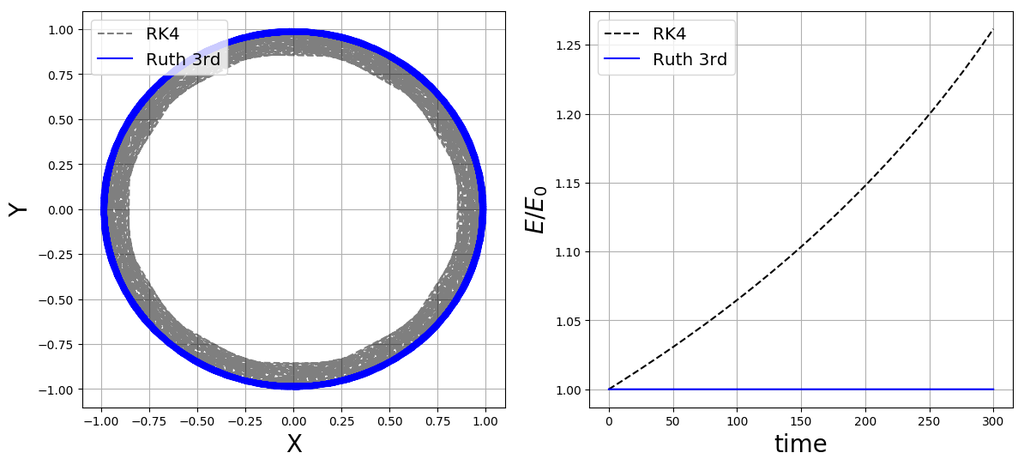

```julia
fig = figure(figsize=(14,6))
subplot(121)
ax=gca()
xlabel("X", size=20)
ylabel("Y", size=20)
ax[:grid]()
ax[:plot](Y[:,1],Y[:,2],"--", color="black", alpha=.5,label="RK4")
ax[:plot](q[:,1],q[:,2], color="blue",label="Ruth 3rd")
ax[:legend](loc="upper left", fontsize="x-large")

subplot(122)
ax=gca()
xlabel("time", size=20)
ylabel(L"$E/E_0$", size=20)
ax[:grid]()
ax[:plot](time,H_rk4/H_rk4[1],"--",color="black", label="RK4")
ax[:plot](time,H_symp/H_symp[1],color="blue", label="Ruth 3rd")
ax[:legend](loc="upper left", fontsize="x-large")
savefig("Kepler_error.pdf")
```